# Bayes KCNQ1 Model Evaluation

Matthew O’Neill

7/6/2022

# Introduction

This document describes our Bayesian penetrance estimation protocol for the KCNQ1-LQT1 genotype-phenotype relationship. We integrate variant-specific features to develop a prior probability of LQT1 manifestation. We update this prior using clinical phenotype counts from variant heterozygotes and population controls to yield a posterior. We evaluate our method using Spearman and Pearson correlations, Brier Scores, and 10-fold cross validation. This work builds on previously published work for SCN5A (PMID: 32569262) and KCNH2 (PMID: 34309407).

Variant-specific data and clinical data are curated in the Bayes KCNQ1 Data Processing RMD. The current document withholds the LQT1-dist metric for each variant being evaluated. For prospective applications, all LQT1-dist information is incorporated.

## Literature and Cohort Combined

```r
# Literature dataset where potentially overlapping carriers/heterozygotes are removed

d <- lit.cohort.data[lit.cohort.data$mut_type == "missense",]

# set initial weighting and penetrance - see materials and methods

d$weight = 1-1/(0.01+d$total_carriers)
d$penetrance_lqt1 <- d$lqt1/d$total_carriers
d[d$total_carriers < 1,"weight"] <- 0.000
```

### LQT1 empirical diagnosis probability prior

Use observed LQT1 diagnosis probability to calculate “LQTS probability density” as described in previous publication. Plot diagnosis probability density versus residue

```r
# Mean squared error

mse <- function(sm) {
  mean((sm$residuals)^2*(sm$weights))
}

# Derive alpha and beta from weighted mean and MSE (estimated variance)

estBetaParams <- function(mu, var) {
  alpha <- ((1 - mu) / var - 1 / mu) * mu ^ 2
  beta <- alpha * (1 / mu - 1)
  return(params = list(alpha = alpha, beta = beta))
}

# Weighted mean to determine lqt1 penetrance empirical prior

newdata = data.frame(wt=1)
model <- lm(penetrance_lqt1 ~ 1, data=d, weights = d$weight)
summary(model)
```

```
##
## Call:
## lm(formula = penetrance_lqt1 ~ 1, data = d, weights = d$weight)
##
## Weighted Residuals:
##      Min       1Q   Median       3Q      Max
## -0.41731 -0.19483 -0.04157  0.06946  0.56486
##
## Coefficients:
##             Estimate Std. Error t value Pr(>|t|)
## (Intercept)  0.41777    0.01497    27.9   <2e-16 ***
## ---
## Signif. codes:  0 '***' 0.001 '**' 0.01 '*' 0.05 '.' 0.1 ' ' 1
##
## Residual standard error: 0.2563 on 629 degrees of freedom
```

```r
p<-predict(model, newdata)
dev<- mse(model) #p*(1-p)

# Estimated shape parameters for lqt1 empirical prior

alpha0 = estBetaParams(p,dev)$alpha
beta0 = estBetaParams(p,dev)$beta
print(paste("alpha0 = ", alpha0, "  beta0 = ", beta0))
```

```
## [1] "alpha0 =  1.13103115117603   beta0 =  1.57629587356151"
```

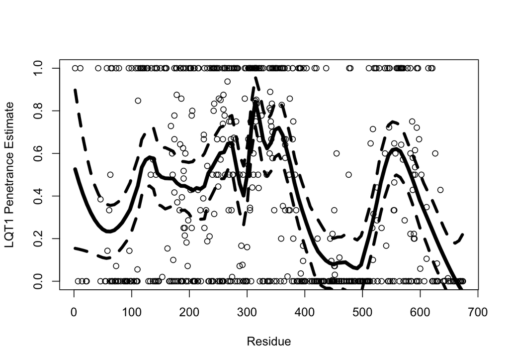

```r
# Bayesian lqt1 penetrance estimates from empirical priors
# and observed affected/unaffected counts:

d$lqt1_penetranceBayesian_initial <- (alpha0 + d[,"lqt1"])/((alpha0 + beta0 + d[,"total_carriers"]))
d$lqt1_penetranceBayesian<-d$lqt1_penetranceBayesian_initial

m<- d %>%
  select(resnum, pmean = penetrance_lqt1) %>%
  mutate(p_mean_smooth = rollmean(pmean, k=20, fill = NA))

# Penetrance estimate by Residue - Supplemental Figure 1

fit <- loess(d[,"penetrance_lqt1"]~as.numeric(d[,"resnum"]), span = 0.15)
plot(d$resnum, d$penetrance_lqt1, xlab ="Residue", ylab = "LQT1 Penetrance Estimate")
xrange <- seq(min(fit$x), max(fit$x), length.out = 100)
ps <- predict(fit, xrange, se=T)
lines(xrange, ps$fit*1, lwd=5)
lines(xrange, (ps$fit+1.96*ps$se.fit)*1, lty=2, lwd=4)
lines(xrange, (ps$fit-1.96*ps$se.fit)*1, lty=2, lwd=4)
```

### Calculate LQTS probability densities and annotate function and structural location

With the updated empirical priors applied to carrier counts, calculate “LQTS probability density” as described in previous publication. !!! NOTE: since these data are truly the “best estimates” we include all variants in the calculation such that unique scores are by residue not by variant.

```r
# Use this model to evaluate

# MODEL 1 - this method for model evaluations - Spearman, 10-fold, and Briers

q1.covariates <- q1.covariates[!is.na(q1.covariates$resnum), ]
q1.covariates[, "lqt1_dist"]<-NA
q1.covariates[, "lqt1_dist_weight"]<-NA
ld<-0
for(rec in 1:nrow(q1.covariates)){
print(rec)
q1.covariates[rec,c("lqt1_dist", "lqt1_dist_weight")] <- funcdist(q1.covariates[rec, "resnum"], q1.covariates[rec, "var"], d[!is.na(d$total_carriers) & d$total_carriers>0 & d$mut_type != "nonsense",], q1dist, "penetrance_lqt1", "sigmoid", 7)
}

# MODEL 2 - this method for future predictions!

#tmp<-data.frame(resnum=NA, lqt1_dist=NA)
#q1.covariates$lqt1_dist<-NA
#q1.covariates$lqt1_dist_weight<-NA
#for(rec in seq(2,676,1)){
#  ld <- funcdist(rec, "var", d, q1dist, "penetrance_lqt1", "sigmoid", 7)
#      q1.covariates[!is.na(q1.covariates$resnum) & q1.covariates$resnum == rec, "lqt1_dist"] <- ld[1]
#      q1.covariates[!is.na(q1.covariates$resnum) & q1.covariates$resnum == rec, "lqt1_dist_weight"] <- ld[2]
#      tmp[rec,c("lqt1_dist", "resnum")]<-c(ld[1], rec)
#}
```

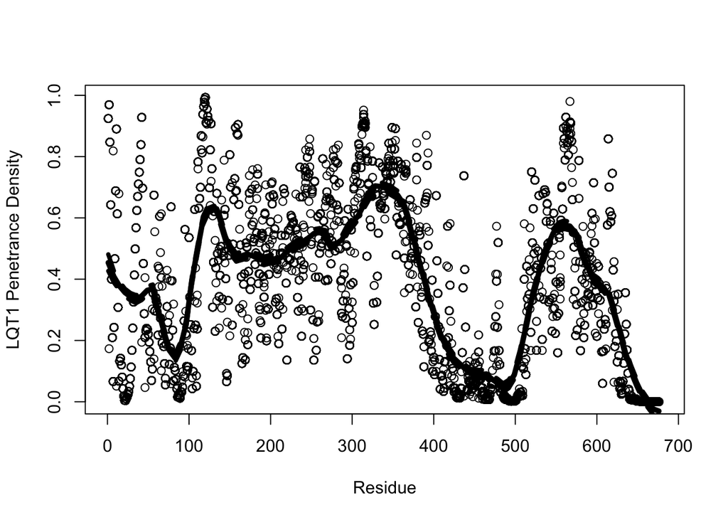

```r
# Plot lqt1_dist versus residue number

q1.covariates$resnum<-as.integer(q1.covariates$resnum)
q1.covariates <- q1.covariates[order(q1.covariates$resnum),]
q1.covariates <- q1.covariates[!is.na(q1.covariates$resnum),]
m<- q1.covariates %>%
  select(resnum, pmean = lqt1_dist) %>%
  mutate(p_mean_smooth = rollmean(pmean, k=20, fill = NA))


# Plot penetrance density by residue - Supplemental Figure 1

fit <- loess(q1.covariates[,"lqt1_dist"]~as.numeric(q1.covariates[,"resnum"]), span = 0.15)
plot(q1.covariates$resnum, q1.covariates$lqt1_dist, xlab ="Residue", ylab = "LQT1 Penetrance Density", xlim=c(0,680))
xrange <- seq(min(fit$x), max(fit$x), length.out = 100)
ps <- predict(fit, xrange, se=T)
lines(xrange, ps$fit*1, lwd=5)
lines(xrange, (ps$fit+1.96*ps$se.fit)*1, lty=2, lwd=4)
lines(xrange, (ps$fit-1.96*ps$se.fit)*1, lty=2, lwd=4)
```

# Merge Clinical Dataframe with Covariate Dataframe

```r
q1.covariates <- distinct(q1.covariates, var, .keep_all = TRUE)
q1.covariates[is.na(q1.covariates$mut_type), "mut_type"] <- "missense"
d$resnum <- as.integer(d$resnum)
d <- merge(d, q1.covariates, all = TRUE)
d[is.na(d$total_carriers), "total_carriers"] <- 0
d <- unique(d)
```

## Calculate EM priors and posteriors for all variants

```r
# Assign p_mean_w to empirical penetrance. The reassignment to ensures
# p_mean_w does not contain "NA"s.

d[is.na(d$lqt1_penetranceBayesian),"lqt1_penetranceBayesian"] <- alpha0/(alpha0+beta0)
d$p_mean_w <- d$lqt1_penetranceBayesian

# reassign "NA"s to 0 in heterozygote counts to enable updating during EM iterations

d[is.na(d$total_carriers),"total_carriers"] <- 0
d[is.na(d$lqt1),"lqt1"] <- 0
d[is.na(d$unaff),"unaff"] <- 0

regression <- function(dv, pivs, nivs, data) {
  # run a linear model with text arguments for dv and ivs
  piv_string <- paste(pivs, collapse=" + ")
  niv_string <- paste(nivs, collapse=" - ")
  if(niv_string!="") iv_string <- paste(piv_string, " - ", niv_string, sep = "")
  if(niv_string=="") iv_string <- paste(piv_string)
  #print(iv_string)
  regression_formula <- as.formula(paste(dv, iv_string, sep=" ~ "))
  #print(regression_formula)
  glm(regression_formula, data, family = quasibinomial(link = "logit"), weights = data[,"weight"])
}

# solve for alpha and beta in Beta distribution

solab <- function(mean, variance){
  alpha <- (mean^2 * (1-mean) - variance * mean)/variance
  beta <- alpha * (1 / mean - 1)
  return(c(alpha,beta))
}

# These 5 features included in the EM algorithm
covariates <- c("blast_pssm", "revel_score", "cardiacboost", "hm_peak", "lqt1_dist")
delta <- 10
count <- 0
tmp<-d[!is.na(d$mut_type) & d$mut_type=="missense" & !is.na(d$lqt1_dist),]
while(delta > 1 & count < 25){ # 5 is roughly a change of 0.5%
  print(paste(delta, count))
  count <- count + 1
  alpha_f <- NULL
  beta_f <- NULL

  for(i in 1:nrow(tmp)){
  newdata = data.frame(var=tmp[i,"var"])
  newdata[covariates] <- tmp[i,covariates]
  model <- regression("p_mean_w", covariates,
                      colnames(newdata)[colSums(is.na(newdata))>0], tmp)
  mean_f <- predict(model, newdata, type = "response")
  variance_f <- (predict(model, newdata,se.fit = T, type = "response")$se.fit)^2
  alpha <- solab(mean_f,variance_f)[1]
  beta <- solab(mean_f,variance_f)[2]
  tmp[i,"prior_mean_w"] <- mean_f
  if(alpha<0.01 | beta<0.01){
    alpha_f[i]=alpha0
    beta_f[i]=beta0
  }else{
    alpha_f[i]=alpha
    beta_f[i]=beta
  }
  }
  new_mean <- (alpha_f + tmp$lqt1)/(alpha_f + beta_f + tmp$total_carriers)

  delta <- sum(abs(new_mean-tmp$p_mean_w))

  tmp$p_mean_w <- new_mean
  print(delta)
}

for (variant in tmp$var){t<-NA;t<-tmp[tmp$var == variant, c("prior_mean_w", "p_mean_w")]; d[d$var == variant, c("prior_mean_w", "p_mean_w")] <- t[1,] }

for (variant in mut_type$var){print(variant);
  if (!is.na(match(variant,d$var)) & !is.na(match(variant, lit.cohort.data$var))) {
    d[d$var == variant, c("lqt1", "unaff","total_carriers")]<-lit.cohort.data[lit.cohort.data$var == variant, c("lqt1", "unaff","total_carriers")]
    }
}

# when tuning parameter is 11, predictions are equivalent to 10 variant heterozygote phenotypes

prior_mean <- d$p_mean_w
variance <- prior_mean*(1-prior_mean)
variance <- variance / 11
ind_a <- seq(1, length(variance),1)
ind_b <- seq(length(variance)+1, length(variance)*2,1)
alpha <- solab(prior_mean,variance)[ind_a]
beta <- solab(prior_mean,variance)[ind_b]

new_mean <- (alpha + d$lqt1)/(alpha + beta + d$total_carriers)
d$p_mean_w <- new_mean
d$prior_mean <- (alpha)/(alpha + beta)
d[d$total_carriers<1,"p_mean_w"]<-d[d$total_carriers<1,"prior_mean_w"]

d$alpha <- alpha
d$beta <- beta

# Save literature data for all variants

save(d,file = "lit_plus_cohort_checkpoint_eval.RData")
```

## Spearman Lit and Cohort merged

```r
# Data for text and Supplemental Table 1

calcPval=function(xName,yName,weightName,nPerms,new.mat2){
  # Pulls out variables

  x=new.mat2[,xName]
  y=new.mat2[,yName]
  w=new.mat2[,weightName]
  x2=x[!is.na(x)]
  y2=y[!is.na(x)]
  w2=w[!is.na(x)]

  # Calculate the real correlation
  realCorr=weightedCorr(x2,y2,method='spearman',weights=w2)
  # Do permutations, calculate fake correlations
  permutedCorrList=c()
  for(permNum in 1:nPerms){
    permutedX=sample(x2,length(x2),replace=FALSE)
    wCorrSim=weightedCorr(permutedX,y2,method='spearman',weights=w2)
    permutedCorrList=c(permutedCorrList,wCorrSim)
  }
  permutedCorrList2=abs(permutedCorrList)
  realCorr2=abs(realCorr)

  # Calculate pvalue
  summ=sum(realCorr2<permutedCorrList2)
  pValue=summ/nPerms
  return(list(realCorr,pValue,length(x2)))
}

calcAllPvals=function(yList,xList,nPerms,weightName,new.mat2){
  i=0
  resultTable=data.frame()
  for(yName in yList){
    for(xName in xList){
      i=i+1
      result=calcPval(xName,yName,weightName,nPerms,new.mat2)
      resultTable[i,'x']=xName
      resultTable[i,'y']=yName
      resultTable[i,'nPerms']=nPerms
      resultTable[i,'weightedCorr']=result[[1]]
      resultTable[i,'pValue']=result[[2]]
      resultTable[i,'n']=result[[3]]
      print(resultTable[i,'pValue'])
    }
  }
  print(resultTable)
  return(resultTable)
}

yList=c('lqt1_penetranceBayesian')
xList=c("lqt1_dist", "cardiacboost",
        'hm_peak','hm_Vhalfact','hm_tauact','hm_taudeact',
        'ht_peak','ht_Vhalfact','ht_tauact','ht_taudeact',
        'pph2_prob', 'provean_score', 'revel_score', "blast_pssm", "prior_mean", "p_mean_w"
        )
tmp<-d[!is.na(d$penetrance_lqt1) & !is.na(d$revel_score),]

resultTable<-calcAllPvals(yList, xList, 1000, 'weight', tmp)
```

```
## [1] 0
## [1] 0
## [1] 0
## [1] 0
## [1] 0.931
## [1] 0.098
## [1] 0
## [1] 0.04
## [1] 0.811
## [1] 0.098
## [1] 0
## [1] 0
## [1] 0
## [1] 0
## [1] 0
```

[output cut: 18 more lines]

```r
# Data for text and Supplemental Table 1

yList=c('lqt1_penetranceBayesian')
xList=c("lqt1_dist", "cardiacboost",
        'hm_peak','hm_Vhalfact','hm_tauact','hm_taudeact',
        'ht_peak','ht_Vhalfact','ht_tauact','ht_taudeact',
        'pph2_prob', 'provean_score', 'revel_score', "blast_pssm", "prior_mean", "p_mean_w"
        )
tmp<-d[!is.na(d$penetrance_lqt1) & !is.na(d$revel_score),]
resultTable<-calcAllPvals(yList, xList, 1000, 'weight', tmp)
```

```
## [1] 0
## [1] 0
## [1] 0
## [1] 0
## [1] 0.931
## [1] 0.093
## [1] 0
## [1] 0.049
## [1] 0.798
## [1] 0.14
## [1] 0
## [1] 0
## [1] 0
## [1] 0
## [1] 0
```

[output cut: 18 more lines]

## Spearman Forest Plots for All Variant Heterozygotes

```r
d2 <- d[!is.na(d$total_carriers) & d$mut_type == "missense",]

tmp<-d2[!is.na(d2$provean_score) & !is.na(d2$revel_score),]
yList=c('lqt1_penetranceBayesian')
xList=c(
        'hm_peak','hm_Vhalfact','hm_tauact','hm_taudeact',
        'ht_peak','ht_Vhalfact','ht_tauact','ht_taudeact',
        "cardiacboost", 'pph2_prob', 'revel_score', 'provean_score',
        "blast_pssm", "lqt1_dist", 'prior_mean_w', 'p_mean_w')
# Heterozygous data is empty in this set! Find out what happened
resultTable<-calcAllPvals(yList, xList, 1000, 'weight', tmp)
```

```
## [1] NA
## [1] NA
## [1] NA
## [1] NA
## [1] NA
## [1] NA
## [1] NA
## [1] NA
## [1] NA
## [1] NA
## [1] NA
## [1] NA
## [1] NA
## [1] NA
## [1] NA
```

[output cut: 18 more lines]

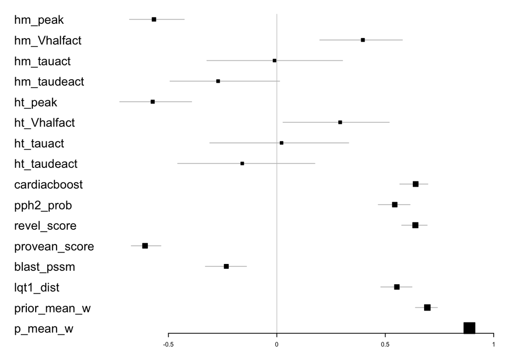

```r
rm(tmp)
rm(t)
i=0
tmp<-data.frame()
for (x in xList){
  i=i+2
  tmp[i-1,"Feature"]<-x
  t<-d[!is.na(d[,x]) & d$total_carriers>0,]
  t<-t[!is.na(t[,"var"]),]
  foo <- boot(t, function(data,indices)
  weightedCorr(t[indices,x],t$penetrance_lqt1[indices], method="spearman", weights = t$weight[indices]), R=1000)
  tmp[i-1,"Spearman"]<-foo$t0
  tmp[i-1,"Spearman_low"]<-quantile(foo$t,c(0.025,0.975), na.rm = T)[1][[1]]
  tmp[i-1,"Spearman_high"]<-quantile(foo$t,c(0.025,0.975), na.rm = T)[2][[1]]
  tmp[i-1,"n"]<-length(t[,x])

}

# Data for Figure 2

forestplot(tmp$Feature,tmp$Spearman,tmp$Spearman_low,tmp$Spearman_high)
```

# 10-fold Crossfold Validation for Spearman, Pearson, and Brier scores

## Import Data

```r
# Works with previous version - optimize on below


#load("lit_plus_cohort_checkpoint_prospective_v2.RData")

# overlap of variants - remove non-unqiues

d <- distinct(d, var, .keep_all = TRUE)
d <- d[d$total_carriers >0 , ]

# index rows randomly - need to randomize rows first in the final

d$ID <- seq.int(nrow(d))
d <- d[sample(nrow(d)),]

# Set prior and posterior to 0 when using saved or loaded data

d$prior_mean_w <- NULL
d$p_mean_w <- NULL
d$alpha <- NULL
d$beta <- NULL

# Only test on data for which we have carriers

d <- d[d$total_carriers > 0, ]

# Turn off warnings to speed computation

options(warn = -1)
```

## Functions for cross fold

```r
regression <- function(dv, pivs, nivs, data) {
  # run a linear model with text arguments for dv and ivs - positive input variable, negative input variable
  piv_string <- paste(pivs, collapse=" + ")
  niv_string <- paste(nivs, collapse=" - ")
  if(niv_string!="") iv_string <- paste(piv_string, " - ", niv_string, sep = "")
  if(niv_string=="") iv_string <- paste(piv_string)
  #print(iv_string)
  regression_formula <- as.formula(paste(dv, iv_string, sep=" ~ "))
  #print(regression_formula)
  glm(regression_formula, data, family = quasibinomial(link = "logit"), weights = data[,"weight"])
}

# solve for alpha and beta in Beta distribution
solab <- function(mean, variance){
  alpha <- (mean^2 * (1-mean) - variance * mean)/variance
  beta <- alpha * (1 / mean - 1)
  return(c(alpha,beta))
}

brier_calc <- function(covariate, outcome, count){
  score <- sum((covariate - outcome)^2)/count
  print(score)
}
```

## 10-fold CV Spearman Cor - Implementation

```r
# Caret package to create 10 folds

d2 <- d
k = 10
kfold = k
d3 <- createFolds(d2$ID, k=kfold)


# Make a vector to host Spearman correlations for ith fold

spearman_cor <- vector("numeric", 10)
j = 0

# Working loop to set ith fold to weight 0!

for(i in d3){
  j = j + 1

# Part 1 - split data

  test <- d2[i,]
  test$weight <- 0
  train <- d2[-i,]
  full <- rbind(test, train) # 10 dataframes where ith variants have weight = 0

# Part 2 - run EM algorithm

full$p_mean_w <- full$penetrance_lqt1

covariates <- c("blast_pssm", "revel_score", "cardiacboost", "hm_peak", "lqt1_dist")

delta <- 10
count <- 0
tmp <- full

options(warn = -1)

while(delta > 1 & count < 25){ # delta = 5 is roughly a change of 0.5%
  print(paste(delta, count))
  count <- count + 1
  alpha_f <- NULL
  beta_f <- NULL

  for(i in 1:nrow(tmp)){
  newdata = data.frame(var=tmp[i,"var"])
  newdata[covariates] <- tmp[i,covariates]
  model <- regression("p_mean_w", covariates,
                      colnames(newdata)[colSums(is.na(newdata))>0], tmp)
  mean_f <- predict(model, newdata, type = "response")
  variance_f <- (predict(model, newdata,se.fit = T, type = "response")$se.fit)^2
  alpha <- solab(mean_f,variance_f)[1]
  beta <- solab(mean_f,variance_f)[2]
  tmp[i,"prior_mean_w"] <- mean_f
  if(alpha<0.01 | beta<0.01){
    alpha_f[i]=alpha0
    beta_f[i]=beta0
  }else{
    alpha_f[i]=alpha
    beta_f[i]=beta
  }
  }
  new_mean <- (alpha_f + tmp$lqt1)/(alpha_f + beta_f + tmp$total_carriers)

  full$prior_mean_w <- tmp$prior_mean_w

  delta <- sum(abs(new_mean-tmp$p_mean_w))

  tmp$p_mean_w <- new_mean

  full$p_mean_w <- tmp$p_mean_w

  print(delta)
}

full2 <- full[full$weight == 0, ]

# Crossfold Validation reported in text and Table 1

spearman_cor[j] <- weightedCorr(full2$lqt1_penetranceBayesian,full2$prior_mean_w,method='spearman',weights= (1-1/(0.01+full2$total_carriers)))

print(full)

}
```

## 10-fold CV Pearson Cor - Implementation

```r
# Caret package to create 10 folds

d2 <- d
k = 10
kfold = k
d3 <- createFolds(d2$ID, k=kfold)


# Make a vector to host Spearman correlations for ith fold

pearson_cor <- vector("numeric", 10)
j = 0

# Working loop to set ith fold to weight 0!

for(i in d3){
  j = j + 1

# Part 1 - split data

  test <- d2[i,]
  test$weight <- 0
  train <- d2[-i,]
  full <- rbind(test, train) # 10 dataframes where ith variants have weight = 0

# Part 2 - run EM algorithm

full$p_mean_w <- full$penetrance_lqt1
covariates <- c("blast_pssm", "revel_score", "cardiacboost", "hm_peak", "lqt1_dist")

delta <- 10
count <- 0
tmp <- full

options(warn = -1)

while(delta > 1 & count < 25){ # delta = 5 is roughly a change of 0.5%
  print(paste(delta, count))
  count <- count + 1
  alpha_f <- NULL
  beta_f <- NULL

  for(i in 1:nrow(tmp)){
  newdata = data.frame(var=tmp[i,"var"])
  newdata[covariates] <- tmp[i,covariates]
  model <- regression("p_mean_w", covariates,
                      colnames(newdata)[colSums(is.na(newdata))>0], tmp)
  mean_f <- predict(model, newdata, type = "response")
  variance_f <- (predict(model, newdata,se.fit = T, type = "response")$se.fit)^2
  alpha <- solab(mean_f,variance_f)[1]
  beta <- solab(mean_f,variance_f)[2]
  tmp[i,"prior_mean_w"] <- mean_f
  if(alpha<0.01 | beta<0.01){
    alpha_f[i]=alpha0
    beta_f[i]=beta0
  }else{
    alpha_f[i]=alpha
    beta_f[i]=beta
  }
  }
  new_mean <- (alpha_f + tmp$lqt1)/(alpha_f + beta_f + tmp$total_carriers)
  full$prior_mean_w <- tmp$prior_mean_w
  delta <- sum(abs(new_mean-tmp$p_mean_w))
  tmp$p_mean_w <- new_mean
  full$p_mean_w <- tmp$p_mean_w
  print(delta)
}

full2 <- full[full$weight == 0, ]

pearson_cor[j] <- weightedCorr(full2$lqt1_penetranceBayesian,full2$prior_mean_w,method='pearson',weights= (1-1/(0.01+full2$total_carriers)))

print(full)

}
```

## 10-fold CV Brier Score - Implementation

```r
# Caret package to create 10 folds

d2 <- d
k = 10
kfold = k
d3 <- createFolds(d2$ID, k=kfold)


# Make a vector to host Brier scores for the ith fold

brier_scores <- vector("numeric", 10)
j = 0

# Working loop to set ith fold to weight 0!

for(i in d3){
  j = j + 1

# Part 1 - split data

  test <- d2[i,]
  test$weight <- 0
  train <- d2[-i,]
  full <- rbind(test, train) # 10 dataframes where ith variants have weight = 0

# Part 2 - run EM algorithm

full$p_mean_w <- full$penetrance_lqt1
covariates <- c("blast_pssm", "revel_score", "cardiacboost", "hm_peak", "lqt1_dist")

# delta to 1 on 1/24/2021

delta <- 10
count <- 0
tmp <- full

options(warn = -1)

while(delta > 1 & count < 25){ # delta = 5 is roughly a change of 0.5%
  print(paste(delta, count))
  count <- count + 1
  alpha_f <- NULL
  beta_f <- NULL

  for(i in 1:nrow(tmp)){
  newdata = data.frame(var=tmp[i,"var"])
  newdata[covariates] <- tmp[i,covariates]
  model <- regression("p_mean_w", covariates,
                      colnames(newdata)[colSums(is.na(newdata))>0], tmp)
  mean_f <- predict(model, newdata, type = "response")
  variance_f <- (predict(model, newdata,se.fit = T, type = "response")$se.fit)^2
  alpha <- solab(mean_f,variance_f)[1]
  beta <- solab(mean_f,variance_f)[2]
  tmp[i,"prior_mean_w"] <- mean_f
  if(alpha<0.01 | beta<0.01){
    alpha_f[i]=alpha0
    beta_f[i]=beta0
  }else{
    alpha_f[i]=alpha
    beta_f[i]=beta
  }
  }
  new_mean <- (alpha_f + tmp$lqt1)/(alpha_f + beta_f + tmp$total_carriers)
  full$prior_mean_w <- tmp$prior_mean_w
  delta <- sum(abs(new_mean-tmp$p_mean_w))
  tmp$p_mean_w <- new_mean
  full$p_mean_w <- tmp$p_mean_w
  print(delta)
}

full2 <- full[full$weight == 0, ]

brier_scores[j] <- brier_calc(full2$lqt1_penetranceBayesian, full2$prior_mean_w, length(full2$lqt1_penetranceBayesian))

print(full)

}
```

## Full Brier scores for other covariates

```r
# Data for Table 1

rm(d)
load('lit_plus_cohort_checkpoint_eval.RData')
d <- d[d$total_carriers >0, ]

# Prior - 0.028

d <- d[!is.na(d$lqt1_penetranceBayesian), ]
d_prior <- d[!is.na(d$prior_mean_w), ]
brier_calc(d_prior$lqt1_penetranceBayesian, d_prior$prior_mean_w, length(d_prior$var))
```

```
## [1] 0.0283781
```

```r
# Posterior - 0.010

d_posterior <- d[!is.na(d$p_mean_w), ]
brier_calc(d_posterior$lqt1_penetranceBayesian, d_posterior$p_mean_w, length(d_posterior$var))
```

```
## [1] 0.01011087
```

```r
# Revel - 0.17

d_revel <- d[!is.na(d$revel_score), ]
brier_calc(d_revel$lqt1_penetranceBayesian, d_revel$revel_score, length(d_revel$var))
```

```
## [1] 0.1667633
```

```r
# LQT1_dist - 0.062

d_lqt1_dist <- d[!is.na(d$lqt1_dist), ]
brier_calc(d_lqt1_dist$lqt1_penetranceBayesian, d_lqt1_dist$lqt1_dist, length(d_lqt1_dist$var))
```

```
## [1] 0.06210016
```

```r
# Cardiac Boost - 0.19

d_cardiacboost <- d[!is.na(d$cardiacboost), ]
brier_calc(d_cardiacboost$lqt1_penetranceBayesian, d_cardiacboost$cardiacboost, length(d_cardiacboost$var))
```

```
## [1] 0.19142
```

```r
# Polyphen - 0.22

d_pph2_prob <- d[!is.na(d$pph2_prob), ]
brier_calc(d_pph2_prob$lqt1_penetranceBayesian, d_pph2_prob$pph2_prob, length(d_cardiacboost$var))
```

```
## [1] 0.2261335
```

## Bootstrap and get the coverage rate

1. Use the observed diagnosis probability from as the TRUE diagnosis probability, generate n binomial observations
2. Use the final EM algorithm posterior as the prior for Beta-Binomial, incorporate data from step (1), generate the posterior distribution, and get 95% credible interval.
3. Check whether the interval cover the true diagnosis probability from Step 1.
4. Repeat Step 1 to Step 3 N times to get the coverage rate.

### Bootstrap function

```r
BootsCoverage <- function(var,n=100,N=1000,true){

  # var: variant name
  # n: number of subjects in the new data
  # N: number of Bootstrap

  # extract the "true" diagnosis probability
  true.p <- d[d$var==var,true]

  # generate binomial data
  event <- rbinom(N,n,true.p)

  # get the posterior credible interval
  alpha <- d$alpha[which(d$var==var)]
  beta <- d$beta[which(d$var==var)]

  new.alpha <- alpha + event
  new.beta <- beta + n - event

  lb <- qbeta(0.025,new.alpha,new.beta)
  ub <- qbeta(0.975,new.alpha,new.beta)

  # change lb to floor of nearest 0.1
  lb <- floor(lb*20)/20
  ub <- ceiling(ub*20)/20

  return(sum(lb < true.p & ub > true.p)/N)
}
```

## Plot coverage

### Observed diagnosis probability as the “true” diagnosis probability

The coverage plot where observed diagnosis probability is the “true” diagnosis probability and one hundred new observations are added is shown below.

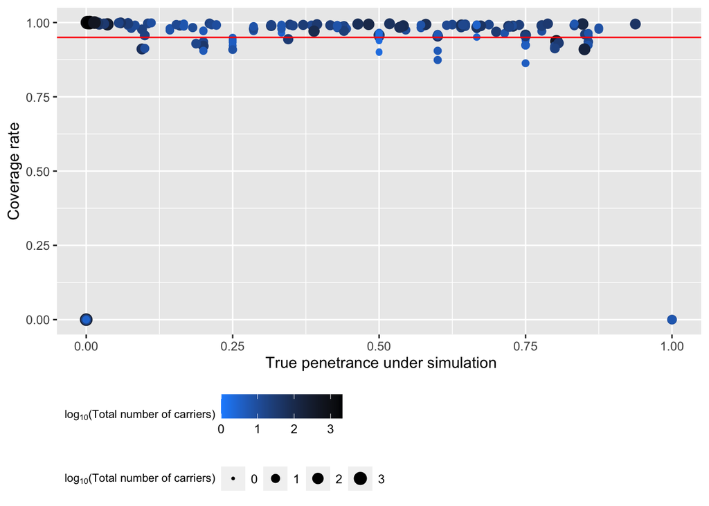